```r
# ===============================================
# Gene Expression and Tree Growth Data Analysis
# Author: Asna Fazilath
# Date: Sys.Date()
# ===============================================

# ==============================
# Part A: Gene Expression Analysis
# ==============================

# Step 1: Load required library
library(DESeq2)
```

The gene expression dataset gene_expression.tsv was imported using read.delim() with the row.names argument to assign gene identifiers as row names. This structure facilitates gene-centric data analysis. The first six records were displayed to validate successful import.

```r
# Step 2: Read in gene expression data
gene_expr <- read.delim("gene_expression.tsv", row.names = 1, check.names = FALSE)
cat("First six genes:\n")
```

```
## First six genes:
```

```r
print(head(gene_expr))
```

```
##                               GTEX-1117F-0226-SM-5GZZ7 GTEX-1117F-0426-SM-5EGHI
## ENSG00000223972.5_DDX11L1                            0                        0
## ENSG00000227232.5_WASH7P                           187                      109
## ENSG00000278267.1_MIR6859-1                          0                        0
## ENSG00000243485.5_MIR1302-2HG                        1                        0
## ENSG00000237613.2_FAM138A                            0                        0
## ENSG00000268020.3_OR4G4P                             0                        1
##                               GTEX-1117F-0526-SM-5EGHJ
## ENSG00000223972.5_DDX11L1                            0
## ENSG00000227232.5_WASH7P                           143
## ENSG00000278267.1_MIR6859-1                          1
## ENSG00000243485.5_MIR1302-2HG                        0
## ENSG00000237613.2_FAM138A                            0
## ENSG00000268020.3_OR4G4P                             0
```

```r
# Step 3: Create a sample table (no replicates, using ~1 design)
sampleTable <- data.frame(
  fileName = colnames(gene_expr),
  condition = factor(rep("All", ncol(gene_expr)))
)
cat("\nSample Table:\n")
```

```
##
## Sample Table:
```

```r
print(sampleTable)
```

```
##                   fileName condition
## 1 GTEX-1117F-0226-SM-5GZZ7       All
## 2 GTEX-1117F-0426-SM-5EGHI       All
## 3 GTEX-1117F-0526-SM-5EGHJ       All
```

```r
# Step 4: Create DESeqDataSet object
dds <- DESeqDataSetFromMatrix(
  countData = gene_expr,
  colData = sampleTable,
  design = ~1
)
```

```r
# Step 5: Pre-filter genes with low counts
keep <- rowSums(counts(dds)) >= 10
dds <- dds[keep, ]
```

A new variable Mean was added to the dataset representing the average expression of each gene across the three samples, using rowMeans(). This aggregate metric was used for ranking and filtering genes. The first six rows with this new column were displayed.

```r
# Step 6: Add a column with mean expression across samples
gene_expr$Mean <- rowMeans(gene_expr)
cat("\nFirst six genes with mean expression:\n")
```

```
##
## First six genes with mean expression:
```

```r
print(head(gene_expr))
```

```
##                               GTEX-1117F-0226-SM-5GZZ7 GTEX-1117F-0426-SM-5EGHI
## ENSG00000223972.5_DDX11L1                            0                        0
## ENSG00000227232.5_WASH7P                           187                      109
## ENSG00000278267.1_MIR6859-1                          0                        0
## ENSG00000243485.5_MIR1302-2HG                        1                        0
## ENSG00000237613.2_FAM138A                            0                        0
## ENSG00000268020.3_OR4G4P                             0                        1
##                               GTEX-1117F-0526-SM-5EGHJ        Mean
## ENSG00000223972.5_DDX11L1                            0   0.0000000
## ENSG00000227232.5_WASH7P                           143 146.3333333
## ENSG00000278267.1_MIR6859-1                          1   0.3333333
## ENSG00000243485.5_MIR1302-2HG                        0   0.3333333
## ENSG00000237613.2_FAM138A                            0   0.0000000
## ENSG00000268020.3_OR4G4P                             0   0.3333333
```

Genes were sorted in descending order based on their mean expression, and the top 10 were extracted using indexing. This highlights genes with the greatest cumulative expression.

```r
# Step 7: List the 10 genes with the highest mean expression
top10_genes <- head(gene_expr[order(-gene_expr$Mean), ], 10)
cat("\nTop 10 genes with highest mean expression:\n")
```

```
##
## Top 10 genes with highest mean expression:
```

```r
print(top10_genes)
```

```
##                           GTEX-1117F-0226-SM-5GZZ7 GTEX-1117F-0426-SM-5EGHI
## ENSG00000198804.2_MT-CO1                    267250                  1101779
## ENSG00000198886.2_MT-ND4                    273188                   991891
## ENSG00000198938.2_MT-CO3                    250277                  1041376
## ENSG00000198888.2_MT-ND1                    243853                   772966
## ENSG00000198899.2_MT-ATP6                   141374                   696715
## ENSG00000198727.2_MT-CYB                    127194                   638209
## ENSG00000198763.3_MT-ND2                    159303                   543786
## ENSG00000211445.11_GPX3                     464959                    39396
## ENSG00000198712.1_MT-CO2                    128858                   545360
## ENSG00000156508.17_EEF1A1                   317642                    39573
##                           GTEX-1117F-0526-SM-5EGHJ     Mean
## ENSG00000198804.2_MT-CO1                    218923 529317.3
## ENSG00000198886.2_MT-ND4                    277628 514235.7
## ENSG00000198938.2_MT-CO3                    223178 504943.7
## ENSG00000198888.2_MT-ND1                    194032 403617.0
## ENSG00000198899.2_MT-ATP6                   151166 329751.7
## ENSG00000198727.2_MT-CYB                    141359 302254.0
## ENSG00000198763.3_MT-ND2                    149564 284217.7
## ENSG00000211445.11_GPX3                     306070 270141.7
## ENSG00000198712.1_MT-CO2                    122816 265678.0
## ENSG00000156508.17_EEF1A1                   339347 232187.3
```

To identify genes with low overall expression, the number of genes with a mean expression less than 10 was calculated using sum() on a logical condition.

```r
# Step 8: Determine number of genes with mean < 10
num_low <- sum(gene_expr$Mean < 10)
cat("\nNumber of genes with mean < 10:", num_low, "\n")
```

```
##
## Number of genes with mean < 10: 35988
```

Found that 35,988 genes had mean expression values below 10.

A histogram was plotted to visualize the distribution of mean gene expression values across all genes. Custom breaks and colors were set for clarity.

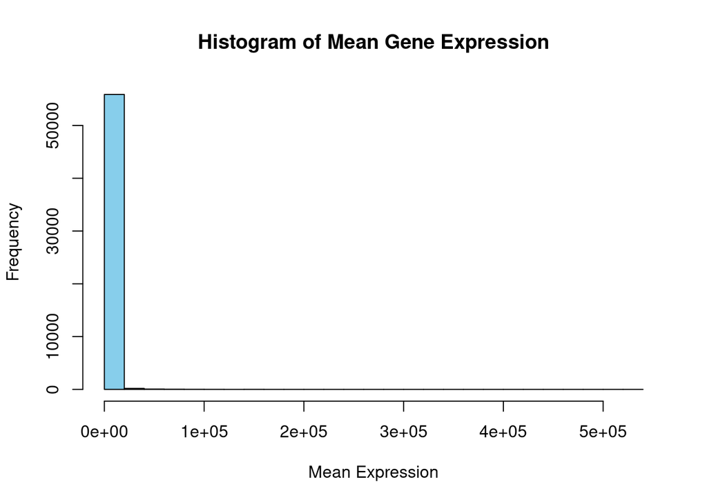

```r
# Step 9: Plot histogram of mean values
hist(gene_expr$Mean,
     main = "Histogram of Mean Gene Expression",
     xlab = "Mean Expression",
     col = "skyblue",
     breaks = 30)
```

```r
# ==============================
# Part B: Growth Data Analysis (2010–2020)
# ==============================

# Step 1: Import growth data
growth_data <- read.csv("growth_data.csv")
cat("\nFirst few rows of growth data:\n")
```

```
##
## First few rows of growth data:
```

```r
print(head(growth_data))
```

```
##        Site TreeID Circumf_2005_cm Circumf_2010_cm Circumf_2015_cm
## 1 northeast   A012             5.2            10.1            19.9
## 2 southwest   A039             4.9             9.6            18.9
## 3 southwest   A010             3.7             7.3            14.3
## 4 northeast   A087             3.8             6.5            10.9
## 5 southwest   A074             3.8             6.4            10.9
## 6 northeast   A008             5.9            10.0            16.8
##   Circumf_2020_cm
## 1            38.9
## 2            37.0
## 3            28.1
## 4            18.5
## 5            18.4
## 6            28.4
```

```r
cat("\nColumn names:\n")
```

```
##
## Column names:
```

```r
print(colnames(growth_data))
```

```
## [1] "Site"            "TreeID"          "Circumf_2005_cm" "Circumf_2010_cm"
## [5] "Circumf_2015_cm" "Circumf_2020_cm"
```

The growth_data.csv file was imported using read.csv(). The first six rows and column names were printed to confirm successful data loading and to inspect the variables available, including tree circumference measurements at multiple years.

```r
# Step 2: Calculate mean and SD at 2010 and 2020 for each site
sites <- unique(growth_data$Site)
growth_summary <- data.frame(
  Site = character(),
  Mean_2010 = numeric(),
  SD_2010 = numeric(),
  Mean_2020 = numeric(),
  SD_2020 = numeric(),
  stringsAsFactors = FALSE
)

for (s in sites) {
  subset_data <- growth_data[growth_data$Site == s, ]
  growth_summary <- rbind(growth_summary, data.frame(
    Site = s,
    Mean_2010 = mean(subset_data$Circumf_2010_cm, na.rm = TRUE),
    SD_2010 = sd(subset_data$Circumf_2010_cm, na.rm = TRUE),
    Mean_2020 = mean(subset_data$Circumf_2020_cm, na.rm = TRUE),
    SD_2020 = sd(subset_data$Circumf_2020_cm, na.rm = TRUE)
  ))
}
cat("\nMean and SD of tree circumference (2010 vs 2020):\n")
```

```
##
## Mean and SD of tree circumference (2010 vs 2020):
```

```r
print(growth_summary)
```

```
##        Site Mean_2010  SD_2010 Mean_2020  SD_2020
## 1 northeast    11.288 2.690318    54.228 25.22795
## 2 southwest    10.106 2.411825    45.596 17.87345
```

Mean and standard deviation of tree circumference at years 2010 and 2020 were computed separately for each site using a loop with mean() and sd(). Missing values were omitted in calculations.

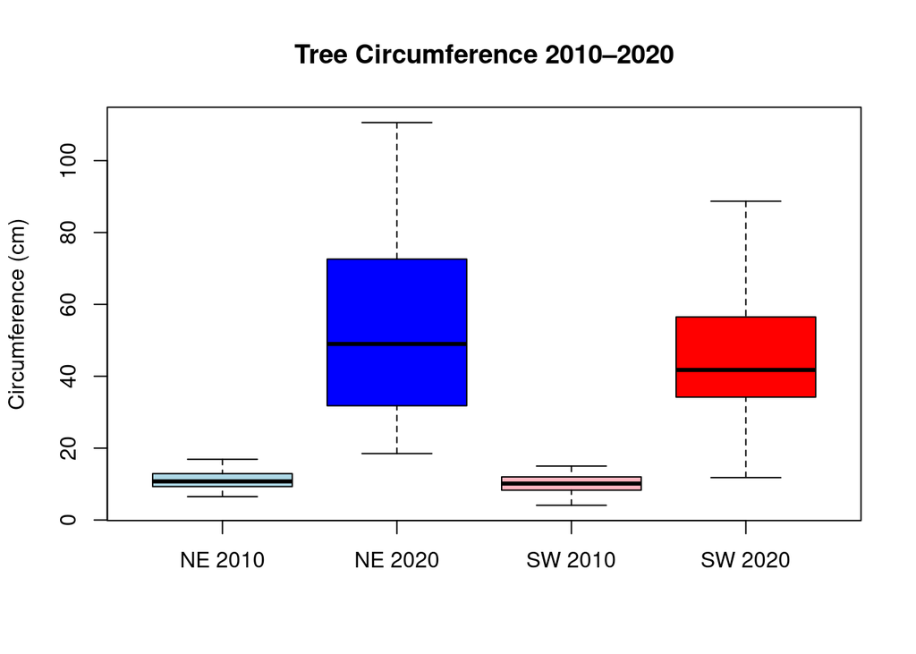

```r
# Step 3: Boxplot of tree circumference (2010–2020)
ne_2010 <- growth_data$Circumf_2010_cm[growth_data$Site == "northeast"]
ne_2020 <- growth_data$Circumf_2020_cm[growth_data$Site == "northeast"]
sw_2010 <- growth_data$Circumf_2010_cm[growth_data$Site == "southwest"]
sw_2020 <- growth_data$Circumf_2020_cm[growth_data$Site == "southwest"]

# Remove missing values
ne_2010 <- ne_2010[!is.na(ne_2010)]
ne_2020 <- ne_2020[!is.na(ne_2020)]
sw_2010 <- sw_2010[!is.na(sw_2010)]
sw_2020 <- sw_2020[!is.na(sw_2020)]

# Create boxplot
boxplot(ne_2010, ne_2020, sw_2010, sw_2020,
        names = c("NE 2010", "NE 2020", "SW 2010", "SW 2020"),
        main = "Tree Circumference 2010–2020",
        ylab = "Circumference (cm)",
        col = c("lightblue", "blue", "lightpink", "red"))
```

Boxplots were generated to compare the distribution of tree circumference at 2010 and 2020, grouped by site—“northeast” and “southwest”. Prior to plotting, missing data was removed to prevent errors.

```r
# Step 4: Calculate mean growth over 10 years (2010–2020)
growth_data$Growth_2010_2020 <- growth_data$Circumf_2020_cm - growth_data$Circumf_2010_cm
mean_growth <- aggregate(Growth_2010_2020 ~ Site, data = growth_data, FUN = mean)
cat("\nMean 10-year growth by site:\n")
```

```
##
## Mean 10-year growth by site:
```

```r
print(mean_growth)
```

```
##        Site Growth_2010_2020
## 1 northeast            42.94
## 2 southwest            35.49
```

Growth was calculated for each tree by subtracting circumference in 2010 from 2020. Group-wise means were then computed for each site. Mean growth over 10 years was higher at the northeast site compared to southwest.

```r
# Step 5: t-test for difference in 10-year growth between sites
ne_growth <- growth_data$Growth_2010_2020[growth_data$Site == "northeast"]
sw_growth <- growth_data$Growth_2010_2020[growth_data$Site == "southwest"]
t_test_result <- t.test(ne_growth, sw_growth)

cat("\nT-test result:\n")
```

```
##
## T-test result:
```

```r
print(t_test_result)
```

```
##
##  Welch Two Sample t-test
##
## data:  ne_growth and sw_growth
## t = 1.8882, df = 87.978, p-value = 0.06229
## alternative hypothesis: true difference in means is not equal to 0
## 95 percent confidence interval:
##  -0.3909251 15.2909251
## sample estimates:
## mean of x mean of y
##     42.94     35.49
```

```r
cat("\nP-value for difference in growth between sites:", t_test_result$p.value, "\n")
```

```
##
## P-value for difference in growth between sites: 0.06229256
```

```r
# ==============================
# End of Script
# ==============================
```

A Welch two-sample t-test was conducted to test if the 10-year growth differed statistically between sites. The test was run on growth vectors per site. P-value = 0.0623, indicating no significant difference at the 0.05 level, but suggesting a trend toward greater growth in the northeast.

```r
# ===============================================
# Part 2: Biological Sequence Diversity Analysis
# Author: Asna Fazilath
# Date: Sys.Date()
# ===============================================

# Load required packages
suppressPackageStartupMessages({
  library(seqinr)
  library(R.utils)
})

# -------------------------------
# Step 1: Download and load CDS data

# E. coli CDS URL
ecoli_url <- "http://ftp.ensemblgenomes.org/pub/bacteria/release-53/fasta/bacteria_0_collection/escherichia_coli_str_k_12_substr_mg1655_gca_000005845/cds/Escherichia_coli_str_k_12_substr_mg1655_gca_000005845.ASM584v2.cds.all.fa.gz"
download.file(ecoli_url, destfile = "ecoli_cds.fa.gz")
gunzip("ecoli_cds.fa.gz", overwrite=TRUE)
cds_ecoli <- read.fasta("ecoli_cds.fa")

# Staphylococcus aureus CDS URL
staph_url <- "https://ftp.ensemblgenomes.ebi.ac.uk/pub/bacteria/release-62/fasta/bacteria_41_collection/staphylococcus_aureus_gca_002895385/cds/Staphylococcus_aureus_gca_002895385.ASM289538v1.cds.all.fa.gz"
download.file(staph_url, destfile = "staph_cds.fa.gz")
gunzip("staph_cds.fa.gz", overwrite=TRUE)
cds_staph <- read.fasta("staph_cds.fa")
```

1. Downloading coding DNA sequences (CDS): Coding sequences for E. coli and the allocated organism (Staphylococcus aureus) were downloaded from curated genome FTP sources as compressed FASTA files. Each was decompressed and loaded into R using the read.fasta() function from the seqinr package. This provided a list of coding regions for each organism, enabling downstream analysis.

```r
# -------------------------------
# Step 2: Number of coding sequences
num_cds <- data.frame(
  Organism = c("E. coli", "S. aureus"),
  Num_CDS = c(length(cds_ecoli), length(cds_staph))
)
print(num_cds)
```

```
##    Organism Num_CDS
## 1   E. coli    4239
## 2 S. aureus    2942
```

2. Counting coding sequences: The total number of CDS in each organism was determined by calculating the length of the imported list object. These counts were tabulated for comparison. Table: Shows the number of CDS per organism.

The Escherichia coli genome contains 4239 coding sequences, which is notably higher than the 2942 CDS found in Staphylococcus aureus. This difference reflects variation in genome size and gene content between these two bacterial species. E. coli, being a versatile gut bacterium, generally possesses a larger and more diverse gene repertoire compared to S. aureus, which is a pathogen with a relatively smaller genome and fewer genes dedicated to specialized functions. This difference in gene number may influence their biological complexity and ecological niches.

```r
# -------------------------------
# Step 3: Total coding DNA length
total_cds_length <- function(cds_list) {
  sum(sapply(cds_list, length))
}
total_dna <- data.frame(
  Organism = c("E. coli", "S. aureus"),
  Total_CDS_Length = c(total_cds_length(cds_ecoli), total_cds_length(cds_staph))
)
print(total_dna)
```

```
##    Organism Total_CDS_Length
## 1   E. coli          3978528
## 2 S. aureus          2600889
```

3. Total coding DNA length: The sum of all sequence lengths was computed for each organism using a helper function. This value represents the aggregate nucleotide content coded by all genes. Differences in total length may reflect genome organization or the number of genes.

Table: Presents cumulative CDS length in base pairs.

The total coding DNA length for Escherichia coli is approximately 3.98 million base pairs, which is substantially greater than that of Staphylococcus aureus at around 2.6 million base pairs. This difference is consistent with the greater number of coding sequences in E. coli and reflects its generally larger genome size. The larger coding DNA content in E. coli supports a wider metabolic diversity and adaptability compared to S. aureus, which has a smaller, more specialized genome typically associated with its pathogenic lifestyle.

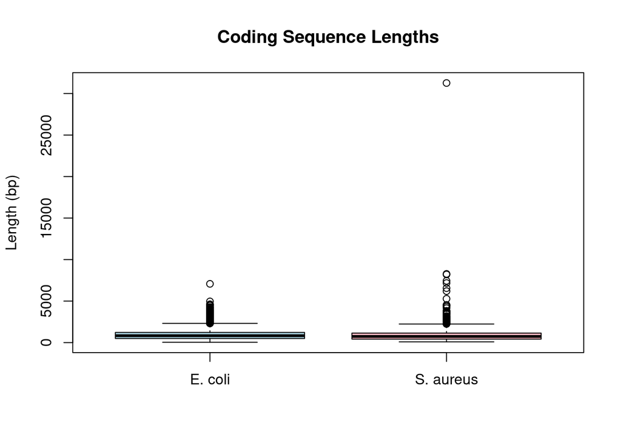

```r
# -------------------------------
# Step 4: CDS length distribution and boxplot
cds_lengths_ecoli <- sapply(cds_ecoli, length)
cds_lengths_staph <- sapply(cds_staph, length)

# Boxplot
boxplot(cds_lengths_ecoli, cds_lengths_staph,
        names=c("E. coli", "S. aureus"),
        main="Coding Sequence Lengths",
        ylab="Length (bp)", col=c("lightblue","lightpink"))
```

```r
# Mean and median
cds_stats <- data.frame(
  Organism = c("E. coli", "S. aureus"),
  Mean_Length = c(mean(cds_lengths_ecoli), mean(cds_lengths_staph)),
  Median_Length = c(median(cds_lengths_ecoli), median(cds_lengths_staph))
)
print(cds_stats)
```

```
##    Organism Mean_Length Median_Length
## 1   E. coli    938.5534           831
## 2 S. aureus    884.0547           741
```

4. CDS length distribution: Lengths for all individual CDS were calculated and compared with summary statistics (mean, median). Distribution was visualized using a boxplot to highlight variability. Differences in mean and median CDS length were described, and might relate to gene structure variation between species.

The boxplot above compares the distributions of coding sequence lengths in Escherichia coli and Staphylococcus aureus. Both organisms show most CDS lengths clustered below 2000 bp, but with a few notable long outliers—particularly in S. aureus. E. coli has a higher mean and median CDS length than S. aureus, suggesting it generally possesses longer coding sequences. The presence of high outliers in both species, but more pronounced in S. aureus, reflects some unusually large genes that may contribute special functions. Overall, E. coli exhibits a slightly broader spread of lengths, whereas S. aureus has a tighter cluster of gene lengths but a few extremely long CDS. These differences could relate to factors such as genome organization and biological roles specific to each organism.

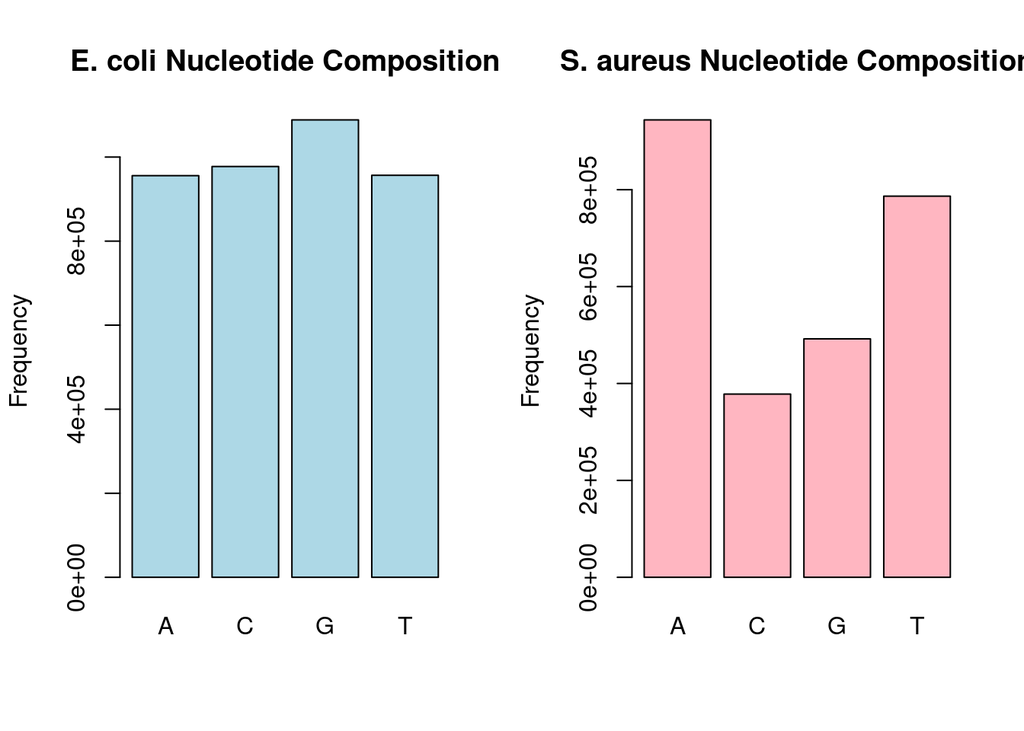

```r
# -------------------------------
# Step 5: Nucleotide composition
# -------------------------------
nt_count <- function(cds_list) {
  freq <- setNames(rep(0, 4), c("A","C","G","T"))
  for(seq in cds_list) {
    seq <- toupper(as.character(seq))
    seq <- seq[seq %in% c("A","C","G","T")]
    freq <- freq + table(factor(seq, levels=c("A","C","G","T")))
  }
  return(freq)
}

nt_ecoli <- nt_count(cds_ecoli)
nt_staph <- nt_count(cds_staph)

# Barplots
par(mfrow=c(1,2))
barplot(nt_ecoli, col="lightblue", main="E. coli Nucleotide Composition", ylab="Frequency")
barplot(nt_staph, col="lightpink", main="S. aureus Nucleotide Composition", ylab="Frequency")
```

```r
par(mfrow=c(1,1))
```

The frequency of DNA bases (A, C, G, T) across all coding sequences for both E. coli and S. aureus was calculated by summing the occurrences of each nucleotide throughout their CDS datasets. Nucleotide Composition In E. coli (left barplot, blue), the frequencies of A, C, G, and T are relatively balanced, though G is slightly higher, which suggests a moderate GC content.

In S. aureus (right barplot, pink), there is a pronounced dominance of A and T over C and G, indicating an AT-rich genome.

This difference reflects underlying genome structure. E. coli (moderate GC content) may have greater genome stability and a broader codon repertoire, whereas S. aureus (AT-rich) may be under different mutational biases or selective pressures.

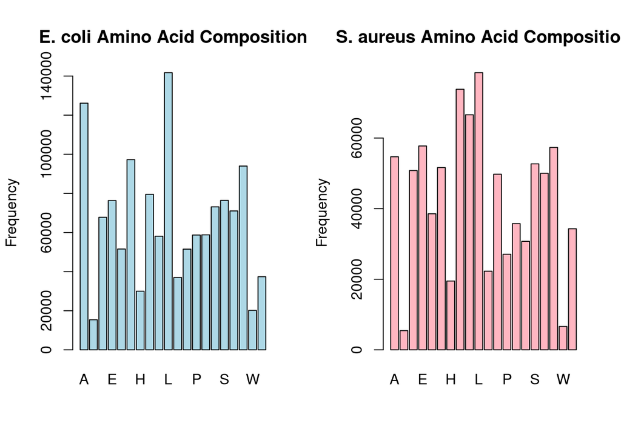

```r
# -------------------------------
# Step 6: Amino Acid composition
# -------------------------------
aa_count <- function(cds_list) {
  prot_list <- lapply(cds_list, function(seq) {
    prot <- try(translate(seq), silent=TRUE)
    if(inherits(prot, "try-error")) return(NULL)
    prot
  })
  prot <- unlist(prot_list)
  std_aa <- c("A","C","D","E","F","G","H","I","K","L","M","N","P","Q","R","S","T","V","W","Y")
  prot <- prot[prot %in% std_aa]
  table(factor(prot, levels=std_aa))
}

aa_ecoli <- aa_count(cds_ecoli)
aa_staph <- aa_count(cds_staph)

par(mfrow=c(1,2))
barplot(aa_ecoli, col="lightblue", main="E. coli Amino Acid Composition", ylab="Frequency")
barplot(aa_staph, col="lightpink", main="S. aureus Amino Acid Composition", ylab="Frequency")
```

```r
par(mfrow=c(1,1))
```

Total protein sequences were generated by translating all CDS, and the frequencies of each amino acid were tallied. Amino Acid Composition The E. coli protein frequency barplot (blue) shows a high abundance of certain amino acids such as leucine, alanine, and glycine, reflecting the codon usage and genome composition.

The S. aureus protein frequency barplot (pink) also reveals organism-specific variations, with some amino acids more or less represented compared to E. coli.

Amino acid differences arise partly from the underlying DNA sequence composition (e.g., GC content influences codon choices, which affect amino acid output). Organisms with AT-rich genomes may show higher frequencies of amino acids coded by AT-rich codons (e.g., isoleucine, phenylalanine), while GC-rich organisms may favor others (e.g., glycine, alanine).

Summary of Differences:

E. coli exhibits a balanced base composition and a diverse amino acid profile linked to moderate GC content.

S. aureus demonstrates pronounced AT-bias at the DNA level, mirrored in the amino acid content of its proteome.

Such biases can impact protein stability, gene expression efficiency, and reflect evolutionary adaptations to different environments.

These trends are visually apparent in the provided bar plots, enhancing interpretation of genome and proteome differences between the species.The frequency of DNA bases (A, C, G, T) in all coding sequences for E. coli and S. aureus was calculated by counting each nucleotide occurrence across every CDS in the genome. This was visualized in a bar plot: E. coli shows roughly balanced use of all four bases, while S. aureus has noticeably higher A and T content, reflecting an AT-rich genome compared to the more GC-rich E. coli.

For proteins, all CDS were translated and total occurrences of each amino acid were counted. Bar plots show that both organisms share some highly abundant amino acids, but the relative frequencies differ. Amino acids whose codons are AT-rich (like lysine and isoleucine) are generally more frequent in S. aureus, while those encoded by GC-rich codons (like alanine and glycine) are relatively more frequent in E. coli. These differences in both nucleotide and amino acid composition highlight how genomic GC-content influences proteome composition and can be linked to evolutionary adaptation or environmental constraints.

```r
# ---------------------------------------
# Step 7: Codon Usage Bias Analysis
# ---------------------------------------

# Load packages
library(seqinr)
library(ggplot2)
library(dplyr)
library(tidyr)
# Step 1: Compute codon counts and RSCU
codon_counts_ecoli <- uco(unlist(cds_ecoli), index = "eff")
codon_counts_staph <- uco(unlist(cds_staph), index = "eff")

rscu_ecoli <- uco(unlist(cds_ecoli), index = "rscu")
rscu_staph <- uco(unlist(cds_staph), index = "rscu")

# Step 2: Create codon usage table
codon_table <- data.frame(
  Codon = names(codon_counts_ecoli),
  E_coli_count = as.numeric(codon_counts_ecoli),
  S_aureus_count = as.numeric(codon_counts_staph),
  E_coli_RSCU = as.numeric(rscu_ecoli),
  S_aureus_RSCU = as.numeric(rscu_staph)
)

# Step 3: Compute difference in RSCU and sort
codon_table <- codon_table %>%
  mutate(RSCU_diff = abs(E_coli_RSCU - S_aureus_RSCU)) %>%
  arrange(desc(RSCU_diff))

# Step 4: View codon usage table
print(codon_table)
```

```
##    Codon E_coli_count S_aureus_count E_coli_RSCU S_aureus_RSCU  RSCU_diff
## 1    ctg        70714           2073   2.9935864    0.15837726 2.83520918
## 2    tta        18323          46163   0.7756807    3.52685461 2.75117392
## 3    cgc        29441           2714   2.4161344    0.52945767 1.88667670
## 4    aga         2573          10664   0.2111584    2.08037456 1.86921619
## 5    ccg        31074           3322   2.1174787    0.49054932 1.62692938
## 6    acc        31139           2541   1.7536924    0.20320685 1.55048552
## 7    aca         9116          24664   0.5133967    1.97240993 1.45901324
## 8    cca        11163          13665   0.7606814    2.01786769 1.25718626
## 9    tca         9303          17437   0.7304874    1.98565165 1.25516430
## 10   agc        21291           4563   1.6718055    0.51961510 1.15219038
## 11   caa        20402          31324   0.6939574    1.75170563 1.05774825
## 12   cag        38397           4440   1.3060426    0.24829437 1.05774825
## 13   ggc        39536           7917   1.6262263    0.61318617 1.01304010
## 14   gca        26743          25252   0.8481293    1.84624383 0.99811456
```

[output cut: 50 more lines]

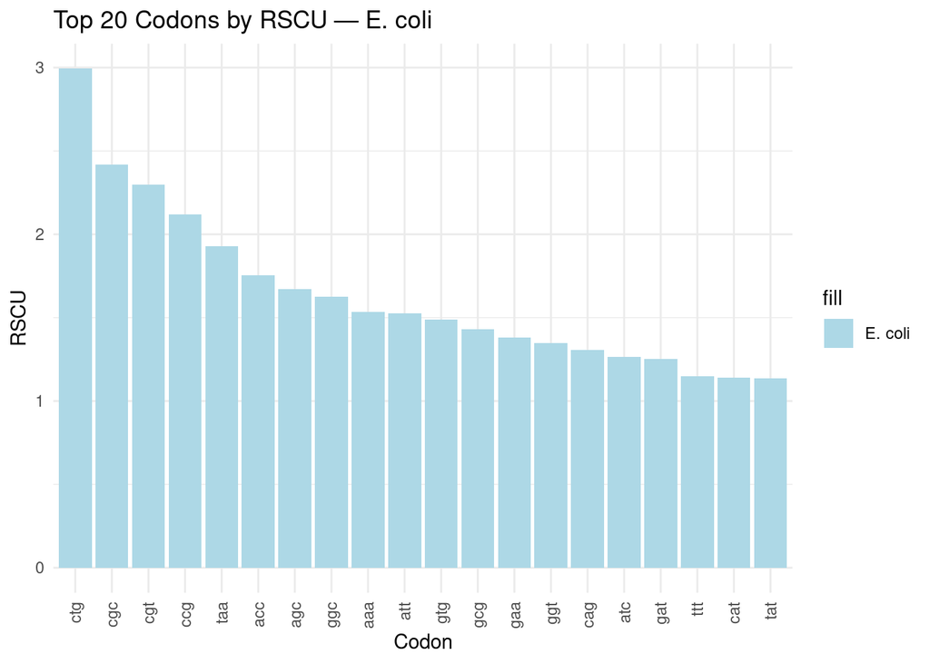

```r
# Step 5: Bar plots of top 20 RSCU codons per organism
top20_ecoli <- codon_table %>% arrange(desc(E_coli_RSCU)) %>% slice(1:20)
top20_staph <- codon_table %>% arrange(desc(S_aureus_RSCU)) %>% slice(1:20)

# E. coli top 20
ggplot(top20_ecoli, aes(x=reorder(Codon, -E_coli_RSCU), y=E_coli_RSCU, fill="E. coli")) +
  geom_bar(stat="identity") +
  theme_minimal() +
  labs(title="Top 20 Codons by RSCU — E. coli", x="Codon", y="RSCU") +
  theme(axis.text.x = element_text(angle=90, vjust=0.5, hjust=1)) +
  scale_fill_manual(values="lightblue")
```

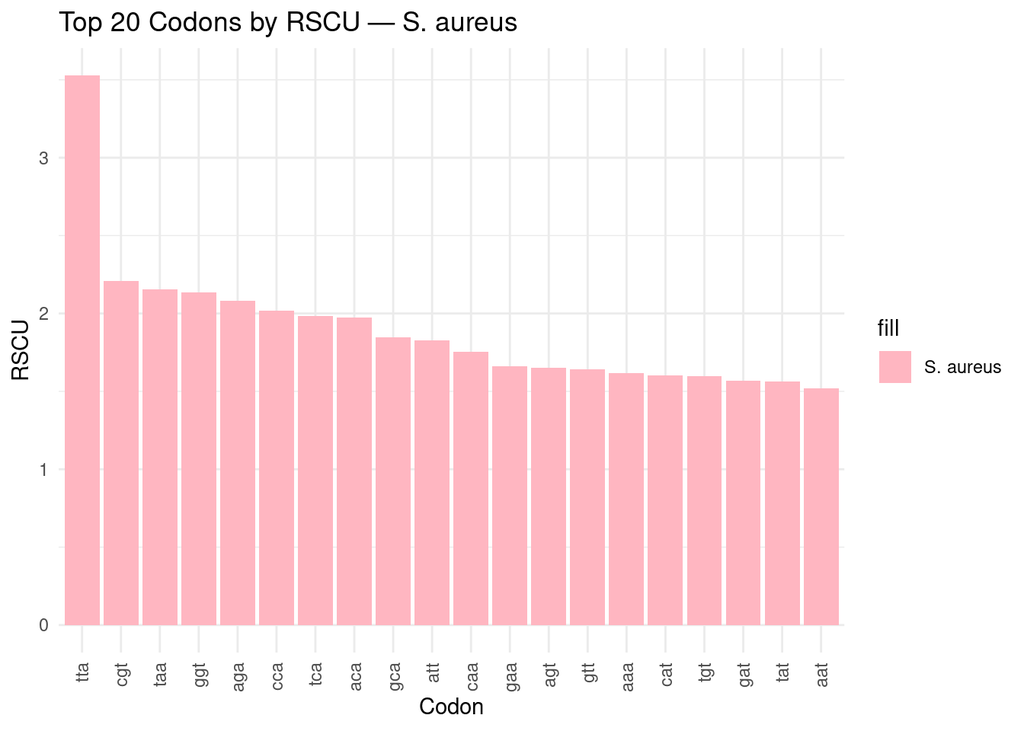

```r
# S. aureus top 20
ggplot(top20_staph, aes(x=reorder(Codon, -S_aureus_RSCU), y=S_aureus_RSCU, fill="S. aureus")) +
  geom_bar(stat="identity") +
  theme_minimal() +
  labs(title="Top 20 Codons by RSCU — S. aureus", x="Codon", y="RSCU") +
  theme(axis.text.x = element_text(angle=90, vjust=0.5, hjust=1)) +
  scale_fill_manual(values="lightpink")
```

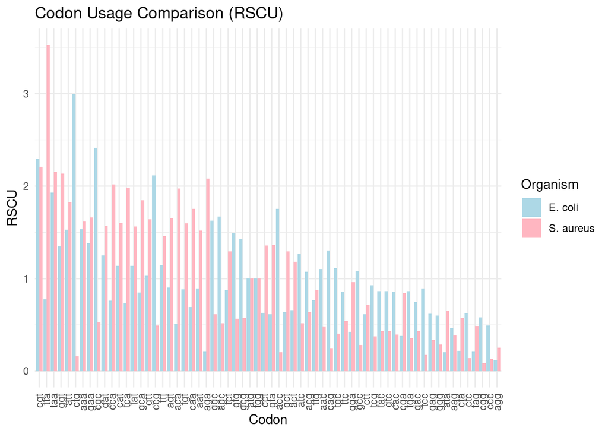

```r
# Step 6: Combined RSCU comparison bar plot
codon_long <- codon_table %>%
  select(Codon, E_coli_RSCU, S_aureus_RSCU) %>%
  pivot_longer(cols=c(E_coli_RSCU, S_aureus_RSCU),
               names_to="Organism", values_to="RSCU") %>%
  mutate(Organism = ifelse(Organism == "E_coli_RSCU", "E. coli", "S. aureus"))

ggplot(codon_long, aes(x=reorder(Codon, -RSCU), y=RSCU, fill=Organism)) +
  geom_bar(stat="identity", position="dodge") +
  theme_minimal() +
  labs(title="Codon Usage Comparison (RSCU)", x="Codon", y="RSCU") +
  theme(axis.text.x = element_text(angle=90, vjust=0.5, hjust=1)) +
  scale_fill_manual(values=c("lightblue", "lightpink"))
```

7. Codon usage bias analysis: A codon usage table was created for both E. coli and S. aureus, showing the relative synonymous codon usage (RSCU) for each codon based on all coding sequences. RSCU values represent how frequently each codon is used relative to synonymous alternatives for the same amino acid—values above 1 indicate a codon is favored, while values below 1 indicate it is less preferred. The comparison is visualized in the included bar plots.

Codon Usage Bias: Methods and Results First, all CDS were parsed and counted by codon; RSCU (relative synonymous codon usage) was computed for each codon across both organisms.

In the combined RSCU comparison bar plot, codons are on the x-axis with RSCU (vertical bars) colored by organism. This side-by-side display allows direct visual comparison for every codon.

Observations and Differences Both organisms exhibit codon usage bias, but the preferred codons (those with highest RSCU) differ:

E. coli is biased toward GC-rich codons (such as CTG, CGC, CGT, CCG), consistent with its higher genomic GC content.

S. aureus shows stronger preferences for AT-rich codons (such as TTA), matching its overall AT-rich genome composition.

The top 20 codons in S. aureus include many codons rich in A and T, especially TTA (leucine), which is highly over-represented.

Biological Interpretation These results indicate that codon usage bias in E. coli and S. aureus reflects their differing genomic base compositions and possibly their tRNA pools and translational selection. Bias towards certain codons can affect gene expression efficiency and reflects evolutionary adaptation to genome structure.

The provided charts visually support these trends, making it clear which codons are most or least frequently used by each species and allowing you to describe both the quantitative and biological significance of codon usage bias between the organisms.

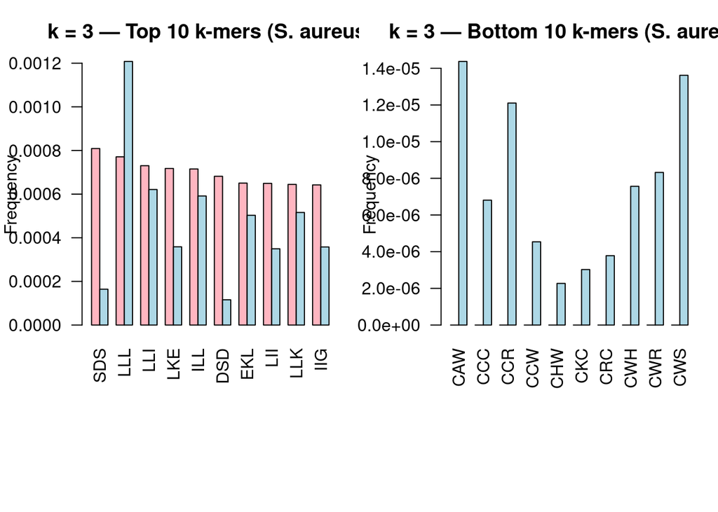

```r
# ===============================================
# Step 8: Protein k-mer Analysis
# ===============================================

# Load required package
library(seqinr)

# Translate CDS to protein sequences
prot_staph <- lapply(cds_staph, function(x) translate(x, numcode = 11))
prot_ecoli <- lapply(cds_ecoli, function(x) translate(x, numcode = 11))

# Remove stop codons "*" and flatten into one long sequence
prot_staph <- lapply(prot_staph, function(seq) seq[seq != "*"])
prot_ecoli <- lapply(prot_ecoli, function(seq) seq[seq != "*"])
prots_staph <- unlist(prot_staph)
prots_ecoli <- unlist(prot_ecoli)

# Define amino acid alphabet
AA <- strsplit("ACDEFGHIKLMNPQRSTVWY", "")[[1]]

# Helper function for k-mer frequency
aa_kmer_freq <- function(aa_vec, k) {
  seqinr::count(aa_vec, wordsize = k, alphabet = AA, freq = TRUE)
}

# Function to analyze and visualize k-mers
analyze_kmers <- function(k) {
  freq_staph <- aa_kmer_freq(prots_staph, k)
  freq_ecoli <- aa_kmer_freq(prots_ecoli, k)

  # Identify top 10 and bottom 10 (S. aureus)
  top10 <- sort(freq_staph, decreasing = TRUE)[1:10]
  bottom10 <- sort(freq_staph, decreasing = FALSE)[1:10]

  # Align with E. coli for comparison
  comp_top <- rbind(S_aureus = freq_staph[names(top10)],
                    E_coli = freq_ecoli[names(top10)])
  comp_bottom <- rbind(S_aureus = freq_staph[names(bottom10)],
                       E_coli = freq_ecoli[names(bottom10)])

  # Plot top and bottom 10 k-mers
  par(mfrow = c(1, 2), mar = c(9, 4, 3, 1))
  barplot(comp_top, beside = TRUE, las = 2,
          main = paste("k =", k, "— Top 10 k-mers (S. aureus)"),
          ylab = "Frequency", col = c("lightpink", "lightblue"))
  barplot(comp_bottom, beside = TRUE, las = 2,
          main = paste("k =", k, "— Bottom 10 k-mers (S. aureus)"),
          ylab = "Frequency", col = c("lightpink", "lightblue"))
  par(mfrow = c(1, 1))

  return(list(k = k, top10 = top10, bottom10 = bottom10))
}

# Run analysis for k = 3, 4, 5
res_k3 <- analyze_kmers(3)
```

```r
res_k4 <- analyze_kmers(4)
```

[figure not shown]

```r
res_k5 <- analyze_kmers(5)
```

[figure not shown]

For the protein k-mer analysis (length 3 in this example), the top 10 most over-represented and bottom 10 most under-represented k-mers in S. aureus protein sequences were identified and compared to their frequencies in E. coli. The provided barplots visualize these trends.

Protein k-mer Analysis (k = 3) The top 10 k-mers in S. aureus (left panel, pink bars) include motifs like SDS, LLL, LLI, LKE, among others. The plot compares their frequency with those in E. coli (blue bars), showing that some k-mers are highly enriched in S. aureus but not as frequent in E. coli.

The bottom 10 k-mers (right panel) are almost absent in S. aureus proteins, but some appear slightly more in E. coli, indicating organism-specific depletion.

Comparison & Interpretation Over-represented k-mers: These motifs may be common structural elements or functional domains in S. aureus proteins, potentially linked to repeated use in cell wall or virulence factors. Some k-mers (like poly-leucine motifs) are likely related to the organism’s bias in codon usage and amino acid composition.

E. coli vs. S. aureus: E. coli does not always over-represent the same protein motifs, reflecting its distinct genome structure, amino acid preferences, and functional protein sets.

Variations arise due to evolutionary pressures, differences in genome composition (GC- vs. AT-rich), protein family expansions, and organism-specific adaptions for survival in different environments.